# Final Project Data Mining

# Introduction

Text analysis is one of the great achievements of Artificial Intelligence and in last few years it has become an important and most popular from of data mining. Text data analysis has become an important part in every analytical fields from social media analytics to fraud detection to spam identification even to the analysing traffic congestion to disaster analysis. In this project we will try to understand how different data mining techniques can help to classify text of a big set of data.

# Board Game Geek Rating Predictor

Board Game Geek is an online platform that discusses content, idea and thoughts of different board games around the world. It has more than two million registered users and one of the largest hub of this kind. BGG includes reviews, ratings, images, play-aids, translations, and session reports from board game enthusiast around the world. Based on all those discussion we will try to predict the rating of the games based on thier reviews and thoughts. We have collected the data of 15 millions reviews from https://www.kaggle.com/jvanelteren/boardgamegeek-reviews. We will try different data minining techniques and will try to find out which techniques will provide the best

# Data Description

Data consist of two sets of data set we will read each data set and will try to understand different data set

```python
import pandas as pd
import numpy as np
df=pd.read_csv('E:/data mining/bgg-15m-reviews.csv')
df
```

|  | Unnamed: 0 | user | rating | comment | ID | name |
| --- | --- | --- | --- | --- | --- | --- |
| 0 | 0 | Torsten | 10.0 | NaN | 30549 | Pandemic |
| 1 | 1 | mitnachtKAUBO-I | 10.0 | Hands down my favorite new game of BGG CON 200... | 30549 | Pandemic |
| 2 | 2 | avlawn | 10.0 | I tend to either love or easily tire of co-op ... | 30549 | Pandemic |
| 3 | 3 | Mike Mayer | 10.0 | NaN | 30549 | Pandemic |
| 4 | 4 | Mease19 | 10.0 | This is an amazing co-op game. I play mostly ... | 30549 | Pandemic |
| ... | ... | ... | ... | ... | ... | ... |
| 15823264 | 15823264 | Fafhrd65 | 8.0 | Turn based preview looks very promising. The g... | 281515 | Company of Heroes |
| 15823265 | 15823265 | PlatinumOh | 8.0 | KS | 281515 | Company of Heroes |
| 15823266 | 15823266 | BunkerBill | 7.0 | NaN | 281515 | Company of Heroes |
| 15823267 | 15823267 | Hattori Hanzo | 6.0 | NaN | 281515 | Company of Heroes |
| 15823268 | 15823268 | Richie2000 | 1.0 | NaN | 281515 | Company of Heroes |

15823269 rows × 6 columns

```python
info=pd.read_csv('E:/data mining/games_detailed_info.csv')
info
```

|  | Unnamed: 0 | type | id | thumbnail | image | primary | alternate | description | yearpublished | minplayers | ... | War Game Rank | Customizable Rank | Children's Game Rank | RPG Item Rank | Accessory Rank | Video Game Rank | Amiga Rank | Commodore 64 Rank | Arcade Rank | Atari ST Rank |
| --- | --- | --- | --- | --- | --- | --- | --- | --- | --- | --- | --- | --- | --- | --- | --- | --- | --- | --- | --- | --- | --- |
| 0 | 0 | boardgame | 30549 | https://cf.geekdo-images.com/thumb/img/HEKrtpT... | https://cf.geekdo-images.com/original/img/j-pf... | Pandemic | ['EPIZOotic', 'Pandemia', 'Pandemia 10 Anivers... | In Pandemic, several virulent diseases have br... | 2008 | 2 | ... | NaN | NaN | NaN | NaN | NaN | NaN | NaN | NaN | NaN | NaN |
| 1 | 1 | boardgame | 822 | https://cf.geekdo-images.com/thumb/img/kqE4YJS... | https://cf.geekdo-images.com/original/img/o4p6... | Carcassonne | ['Carcassonne Jubilee Edition', 'Carcassonne: ... | Carcassonne is a tile-placement game in which ... | 2000 | 2 | ... | NaN | NaN | NaN | NaN | NaN | NaN | NaN | NaN | NaN | NaN |
| 2 | 2 | boardgame | 13 | https://cf.geekdo-images.com/thumb/img/g8LvJsd... | https://cf.geekdo-images.com/original/img/A-0y... | Catan | ['CATAN', 'Catan (Колонизаторы)', 'Catan telep... | In Catan (formerly The Settlers of Catan), pla... | 1995 | 3 | ... | NaN | NaN | NaN | NaN | NaN | NaN | NaN | NaN | NaN | NaN |
| 3 | 3 | boardgame | 68448 | https://cf.geekdo-images.com/thumb/img/Grz-qM9... | https://cf.geekdo-images.com/original/img/3DP_... | 7 Wonders | ['7 csoda', '7 Cudów Świata', '7 divů světa', ... | You are the leader of one of the 7 great citie... | 2010 | 2 | ... | NaN | NaN | NaN | NaN | NaN | NaN | NaN | NaN | NaN | NaN |
| 4 | 4 | boardgame | 36218 | https://cf.geekdo-images.com/thumb/img/iPlTR5c... | https://cf.geekdo-images.com/original/img/oN8C... | Dominion | ['Dominion: Basisspiel', 'Dominion: In naam va... | &quot;You are a monarch, like your parents bef... | 2008 | 2 | ... | NaN | NaN | NaN | NaN | NaN | NaN | NaN | NaN | NaN | NaN |
| ... | ... | ... | ... | ... | ... | ... | ... | ... | ... | ... | ... | ... | ... | ... | ... | ... | ... | ... | ... | ... | ... |
| 19225 | 19225 | boardgame | 246345 | https://cf.geekdo-images.com/thumb/img/EMAGbmG... | https://cf.geekdo-images.com/original/img/UxAl... | Ninja Rush | ['Ternet Ninja'] | In Ninja Rush, on each ninja player's turn, th... | 2018 | 2 | ... | NaN | NaN | NaN | NaN | NaN | NaN | NaN | NaN | NaN | NaN |
| 19226 | 19226 | boardgame | 195623 | https://cf.geekdo-images.com/thumb/img/y2EuGgf... | https://cf.geekdo-images.com/original/img/o9Ut... | Politricks: Dirty Card Game | NaN | Want another way to analyze aspiring politicia... | 2016 | 2 | ... | NaN | NaN | NaN | NaN | NaN | NaN | NaN | NaN | NaN | NaN |
| 19227 | 19227 | boardgame | 235943 | https://cf.geekdo-images.com/thumb/img/LUyoD4j... | https://cf.geekdo-images.com/original/img/o9gV... | Doppel X | NaN | In Doppel X, players throw their dice together... | 2017 | 3 | ... | NaN | NaN | NaN | NaN | NaN | NaN | NaN | NaN | NaN | NaN |
| 19228 | 19228 | boardgame | 284862 | https://cf.geekdo-images.com/thumb/img/b_ckSKO... | https://cf.geekdo-images.com/original/img/Vxd9... | Beasty Borders | NaN | Both players want to make the biggest groups w... | 2019 | 2 | ... | NaN | NaN | NaN | NaN | NaN | NaN | NaN | NaN | NaN | NaN |
| 19229 | 19229 | boardgame | 281515 | https://cf.geekdo-images.com/thumb/img/QnvFHRq... | https://cf.geekdo-images.com/original/img/pC4x... | Company of Heroes | NaN | Company of Heroes the board game is based on t... | 2020 | 2 | ... | 2717.0 | NaN | NaN | NaN | NaN | NaN | NaN | NaN | NaN | NaN |

19230 rows × 56 columns

We have 15823269 reviews of 19230 games. But there are some ratings that does not have any comments or reviews. So we will remove those comments.

```python
df1=df[~df.comment.str.contains("NaN",na=True)]
df1
```

|  | Unnamed: 0 | user | rating | comment | ID | name |
| --- | --- | --- | --- | --- | --- | --- |
| 1 | 1 | mitnachtKAUBO-I | 10.0 | Hands down my favorite new game of BGG CON 200... | 30549 | Pandemic |
| 2 | 2 | avlawn | 10.0 | I tend to either love or easily tire of co-op ... | 30549 | Pandemic |
| 4 | 4 | Mease19 | 10.0 | This is an amazing co-op game. I play mostly ... | 30549 | Pandemic |
| 5 | 5 | cfarrell | 10.0 | Hey! I can finally rate this game I've been pl... | 30549 | Pandemic |
| 8 | 8 | gregd | 10.0 | Love it- great fun with my son. 2 plays so far... | 30549 | Pandemic |
| ... | ... | ... | ... | ... | ... | ... |
| 15823242 | 15823242 | ChiefMe | 10.0 | KS Collector's Bundle with a friend of mine | 281515 | Company of Heroes |
| 15823247 | 15823247 | Mukaz | 10.0 | Belekokio Gerumo... | 281515 | Company of Heroes |
| 15823253 | 15823253 | jpaquila | 10.0 | Excelente!! lo mejor que probé. | 281515 | Company of Heroes |
| 15823264 | 15823264 | Fafhrd65 | 8.0 | Turn based preview looks very promising. The g... | 281515 | Company of Heroes |
| 15823265 | 15823265 | PlatinumOh | 8.0 | KS | 281515 | Company of Heroes |

2995022 rows × 6 columns

After removing the empty rows we have 2995022 reviews and ratings. Next we will shuffle the data so that we have a good homogenous mix of data

```python
from sklearn.utils import shuffle
df1=shuffle(df1,random_state=0)
df1
```

|  | Unnamed: 0 | user | rating | comment | ID | name |
| --- | --- | --- | --- | --- | --- | --- |
| 40545 | 40545 | chessduffer | 10.0 | Believe the Hype, This game is completely awes... | 31260 | Agricola |
| 11354135 | 11354135 | seaapple | 6.5 | Fun card game that plays like a board game. F... | 72 | Verräter |
| 866088 | 866088 | ingmen | 9.0 | Light family game with a deep gameplay. | 230802 | Azul |
| 5392690 | 5392690 | Phoenixio | 9.0 | Calgary | 176396 | Quadropolis |
| 6860438 | 6860438 | Sops | 8.0 | When this is great, this is really really grea... | 27708 | 1960: The Making of the President |
| ... | ... | ... | ... | ... | ... | ... |
| 12793936 | 12793936 | _The_Inquiry_ | 3.0 | Prior to 2020: 1 play | 22889 | Pictureka! |
| 6256575 | 6256575 | Khexhu | 5.0 | Prefer the 1942 edition greatly over this one. | 98 | Axis & Allies |
| 12637155 | 12637155 | billymoustache | 8.0 | Solo'd | 245961 | Fleet: The Dice Game |
| 9142174 | 9142174 | R3DSH1FT | 5.0 | Once the novelty wears off there's not a whole... | 72321 | The Networks |
| 1979742 | 1979742 | wmshub | 7.0 | Nice two player card game. Reminds me a bit of... | 54043 | Jaipur |

2995022 rows × 6 columns

```python
import matplotlib.pyplot as plt
```

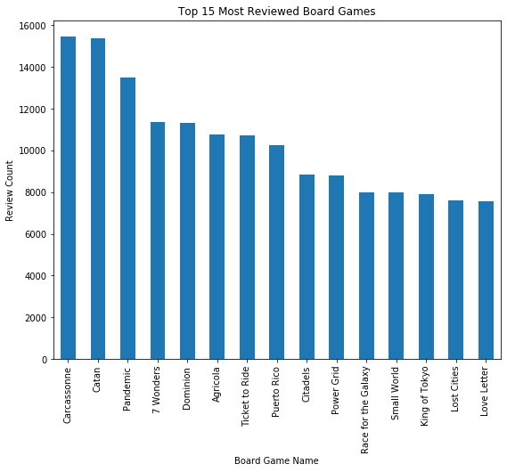

```python
plt.figure(figsize=(9, 7))
df.loc[df['comment'].notna()]['name'].value_counts()[:15].plot(kind='bar')
plt.xlabel('Board Game Name')
plt.ylabel('Review Count')
plt.title('Top 15 Most Reviewed Board Games')
plt.show()
```

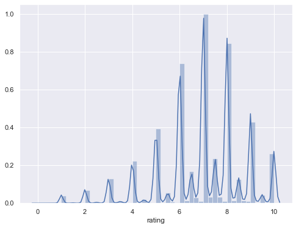

```python
import seaborn as sns
plt.figure(figsize=(8, 6))
sns.set(color_codes="True")
sns.distplot(df1["rating"])
```

From the two figure we can see the most reviewed board game are- Carcassonne, Catan, Pandemic, 7 Wonders and Dominion. 2nd figure shows that the most common ratings are in between 6 and 9

Next we will divide the data set as follows- Train data set=60% Development data set =20% Test Data set=20%

```python
print('Train Data Set ')
df1_train=df1[:1797013]
df1_train
```

```
Train Data Set
```

|  | Unnamed: 0 | user | rating | comment | ID | name |
| --- | --- | --- | --- | --- | --- | --- |
| 40545 | 40545 | chessduffer | 10.0 | Believe the Hype, This game is completely awes... | 31260 | Agricola |
| 11354135 | 11354135 | seaapple | 6.5 | Fun card game that plays like a board game. F... | 72 | Verräter |
| 866088 | 866088 | ingmen | 9.0 | Light family game with a deep gameplay. | 230802 | Azul |
| 5392690 | 5392690 | Phoenixio | 9.0 | Calgary | 176396 | Quadropolis |
| 6860438 | 6860438 | Sops | 8.0 | When this is great, this is really really grea... | 27708 | 1960: The Making of the President |
| ... | ... | ... | ... | ... | ... | ... |
| 11507198 | 11507198 | ravenme | 8.0 | Good game, one of the best worker placement ga... | 173442 | Empires: Age of Discovery |
| 4330642 | 4330642 | MikeTuna | 8.0 | This is a game that I feel like I'm trying rea... | 154203 | Imperial Settlers |
| 7447203 | 7447203 | gumbomasta | 9.3 | What a wild and wooly experience. | 105551 | Archipelago |
| 361422 | 361422 | goldeneyeace | 9.0 | A deceptively simple 2-player game, which expe... | 54043 | Jaipur |
| 1637414 | 1637414 | h_zeera | 7.0 | The teach is a bit long, but the theme and mec... | 158899 | Colt Express |

1797013 rows × 6 columns

```python
print('Development Data Set')
df1_dev=df1[1797013:2396017]
df1_dev
```

```
Development Data Set
```

|  | Unnamed: 0 | user | rating | comment | ID | name |
| --- | --- | --- | --- | --- | --- | --- |
| 3946069 | 3946069 | bigmac33070 | 9.5 | Just epic in its scope, which I adore on so ma... | 12493 | Twilight Imperium (Third Edition) |
| 7907007 | 7907007 | pavin | 6.0 | Jeu du "trou-de-cul" | 929 | The Great Dalmuti |
| 9476696 | 9476696 | JohnRayJr | 6.0 | Middle Earth Quest seems to follow a recent (?... | 31563 | Middle-Earth Quest |
| 8703813 | 8703813 | ansonvergens | 9.0 | Greek Edition | 194880 | Dream Home |
| 6732511 | 6732511 | fraludico | 7.0 | Italian edition. | 140 | Pit |
| ... | ... | ... | ... | ... | ... | ... |
| 14915469 | 14915469 | stefanmiker | 6.8 | A Great Boardgame about the American Civil War... | 14701 | The Price of Freedom: The American Civil War 1... |
| 10064164 | 10064164 | alexgrant | 7.5 | A little unsure after the first game; enjoyabl... | 141517 | A Study in Emerald |
| 10087684 | 10087684 | Roarket | 7.0 | Components a little fiddly to setup at start | 217085 | Unearth |
| 15816828 | 15816828 | David Ells | 8.0 | Kickstarter! | 171500 | El Dorado Canyon |
| 5263014 | 5263014 | denngeki | 6.0 | 2-4/4 | 2653 | Survive: Escape from Atlantis! |

599004 rows × 6 columns

```python
print('Test Data Set')
df1_test=df1[2396017:]
df1_test
```

```
Test Data Set
```

|  | Unnamed: 0 | user | rating | comment | ID | name |
| --- | --- | --- | --- | --- | --- | --- |
| 10257598 | 10257598 | Large Deviator | 9.0 | For details, look at my review: http://www.boa... | 43022 | Yomi |
| 13993328 | 13993328 | oskari | 5.0 | A boring deduction game. Way too little hidden... | 756 | Black Vienna |
| 13246020 | 13246020 | zonk67 | 9.0 | Update: I stand corrected. 2nd edition is the ... | 221769 | Bios: Megafauna (Second Edition) |
| 15078008 | 15078008 | Kaixo | 4.0 | Mass market nonsense. Theme implementation is... | 232944 | Where in the World is Carmen Sandiego? Card Game |
| 3471856 | 3471856 | alarii | 2.0 | Solo Rating ! | 167791 | Terraforming Mars |
| ... | ... | ... | ... | ... | ... | ... |
| 12793936 | 12793936 | _The_Inquiry_ | 3.0 | Prior to 2020: 1 play | 22889 | Pictureka! |
| 6256575 | 6256575 | Khexhu | 5.0 | Prefer the 1942 edition greatly over this one. | 98 | Axis & Allies |
| 12637155 | 12637155 | billymoustache | 8.0 | Solo'd | 245961 | Fleet: The Dice Game |
| 9142174 | 9142174 | R3DSH1FT | 5.0 | Once the novelty wears off there's not a whole... | 72321 | The Networks |
| 1979742 | 1979742 | wmshub | 7.0 | Nice two player card game. Reminds me a bit of... | 54043 | Jaipur |

599005 rows × 6 columns

# Data Pre-processing

We will do multiple steps to preprocess the text data.

Lowercasing: It is one of effective prepocessing way of the text data. It helps to provide consistent data for different reviews and will help to provide more accurate data set.

Stop words removal: Stop words is a set of of common words that are very common in almost all type of sentences. One of the example of stop words are- “a”, “the”, “is”, “are” and etc. Stop words often provide misleading results and is a very important tool for text data analysis.

Remove Punctuations: Removing different punctuations i.e. http//, @, different symbols(",',?,!) will also provide more accurate results

Tokenization: Tokenization is the process of tokenizing or splitting a string, text into a list of tokens. One can think of token as parts like a word is a token in a sentence, and a sentence is a token in a paragraph. It helps to calculate the frequency of words

```python
pip install wordcloud
```

```python
import nltk
from nltk.corpus import stopwords
from nltk.stem.porter import PorterStemmer
from wordcloud import WordCloud,STOPWORDS
from nltk.stem import WordNetLemmatizer
from nltk.tokenize import word_tokenize,sent_tokenize
from bs4 import BeautifulSoup
import re,string,unicodedata
from sklearn.metrics import classification_report,confusion_matrix,accuracy_score
from sklearn.model_selection import train_test_split
from string import punctuation

import matplotlib.pyplot as plt
import seaborn as sns
nltk.download('stopwords')
```

```
True
```

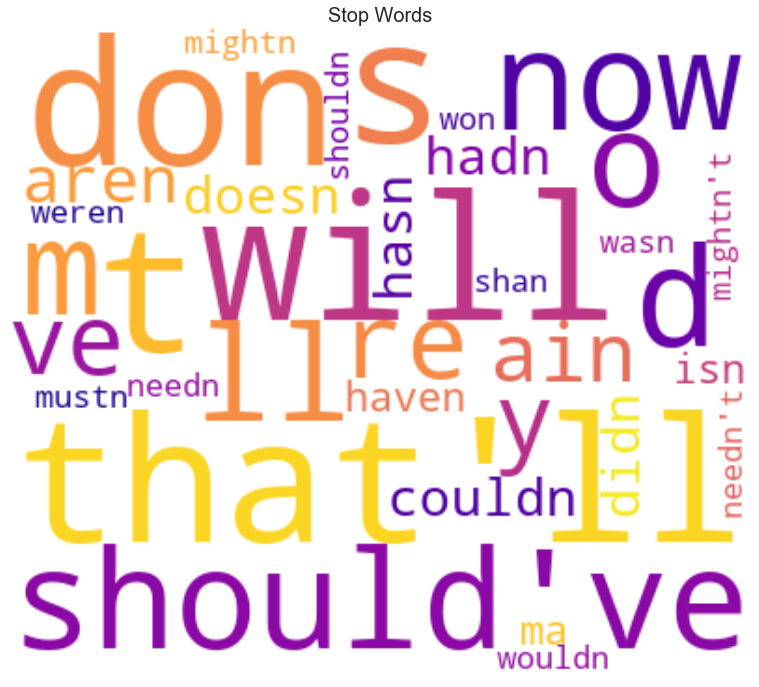

```python
stop_word = stopwords.words('english')
new=' '.join([str(elem) for elem in stop_word])
from wordcloud import WordCloud
import matplotlib.pyplot as plt
wc = WordCloud(width=400, height=350,colormap='plasma',background_color='white').generate(new)
plt.figure(figsize=(15,12))
plt.imshow(wc, interpolation='bilinear')
plt.title('Stop Words', fontsize=20)
plt.axis('off');
plt.show()
```

```python
def clean(text):
    text = re.sub(r'http\S+', " ", text)
    text = re.sub(r'@\w+',' ',text)
    text = re.sub(r'#\w+', ' ', text)
    text = re.sub(r'\d+', ' ', text)
    text = re.sub('r<.*?>',' ', text)
    text = text.split()
    text = " ".join([word for word in text if not word in stop_word])


    return text
```

```python
train=df1_train['comment'].str.lower()
train
```

```
40545       believe the hype, this game is completely awes...
11354135    fun card game that plays like a board game.  f...
866088                light family game with a deep gameplay.
5392690                                               calgary
6860438     when this is great, this is really really grea...
                                  ...
11507198    good game, one of the best worker placement ga...
4330642     this is a game that i feel like i'm trying rea...
7447203                     what a wild and wooly experience.
361422      a deceptively simple 2-player game, which expe...
1637414     the teach is a bit long, but the theme and mec...
Name: comment, Length: 1797013, dtype: object
```

```python
train_new=train.apply(lambda x:clean(x))
train_new
```

```
40545       believe hype, game completely awesome. reminds...
11354135    fun card game plays like board game. feels lik...
866088                       light family game deep gameplay.
5392690                                               calgary
6860438     great, really really great! card mechanic to-i...
                                  ...
11507198    good game, one best worker placement games the...
4330642     game feel like i'm trying really hard like. th...
7447203                                wild wooly experience.
361422      deceptively simple -player game, expertly side...
1637414     teach bit long, theme mechanics pair well usua...
Name: comment, Length: 1797013, dtype: object
```

```python
def tokenize_remove_punctuations(x):                # Tokenize the text into tokens and count their frequencies
    wordfreq = {}
    for txt in x:
        tokens = nltk.RegexpTokenizer(r"\w+").tokenize(txt)     # we could use .lower().split()
        for token in tokens:                                    # and remove the punctuations
            if token not in wordfreq.keys():
                wordfreq[token] = 1
            else:
                wordfreq[token] += 1

    return wordfreq
def sort_words_freq(wordfreq_X):                    # Sort words frequency in reverse order
    wordfreq_sorted = dict(sorted(wordfreq_X.items(), key=lambda x: x[1], reverse=True))
    return wordfreq_sorted
def delete_threshold(wordfreq_sorted):
    delete = []
    for key, val in wordfreq_sorted.items():
        if val < 1000 :
            delete.append(key)

    for i in delete:
        del wordfreq_sorted[i]
    return   wordfreq_sorted
```

```python
wordfreq_X = tokenize_remove_punctuations(train_new)
wordfreq_X2 = sort_words_freq(wordfreq_X)
wordfreq_X3=delete_threshold(wordfreq_X2)
```

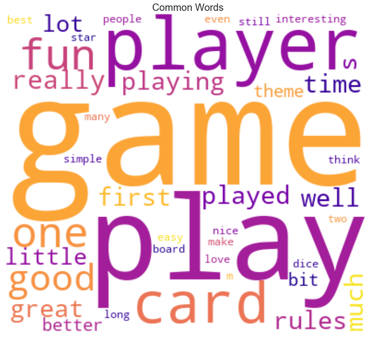

```python
words=[k  for  k in  wordfreq_X3.keys()]
word=words[:50]
new=' '.join([str(elem) for elem in word])
from wordcloud import WordCloud
import matplotlib.pyplot as plt
wc = WordCloud(width=400, height=350,colormap='plasma',background_color='white').generate(new)
plt.figure(figsize=(15,12))
plt.imshow(wc, interpolation='bilinear')
plt.title('Common Words', fontsize=20)
plt.axis('off');
plt.show()
```

```python
x_train=train_new
y_train=df1_train['rating']
```

```python
dev=df1_dev['comment'].str.lower()
dev_new=dev.apply(lambda x:clean(x))
x_dev=dev_new
y_dev=df1_dev['rating']
print(x_dev)
print(y_dev)
```

```
3946069     epic scope, adore many levels. really enjoy ra...
7907007                                  jeu du "trou-de-cul"
9476696     middle earth quest seems follow recent (?) tre...
8703813                                         greek edition
6732511                                      italian edition.
                                  ...
14915469    great boardgame american civil war!!!incredibl...
10064164    little unsure first game; enjoyable however. d...
10087684                 components little fiddly setup start
15816828                                         kickstarter!
5263014                                                   - /
Name: comment, Length: 599004, dtype: object
3946069     9.5
7907007     6.0
9476696     6.0
8703813     9.0
6732511     7.0
           ...
14915469    6.8
10064164    7.5
10087684    7.0
15816828    8.0
5263014     6.0
Name: rating, Length: 599004, dtype: float64
```

```python
test=df1_test['comment'].str.lower()
test_new=test.apply(lambda x:clean(x))
x_test=test_new
y_test=df1_test['rating']
print(x_test)
print(y_test)
```

```
10257598                                details, look review:
13993328    boring deduction game. way little hidden infor...
13246020    update: stand corrected. nd edition better ove...
15078008    mass market nonsense. theme implementation dec...
3471856                                         solo rating !
                                  ...
12793936                                         prior : play
6256575                           prefer edition greatly one.
12637155                                               solo'd
9142174     novelty wears there's whole lot going games fe...
1979742     nice two player card game. reminds bit traders...
Name: comment, Length: 599005, dtype: object
10257598    9.0
13993328    5.0
13246020    9.0
15078008    4.0
3471856     2.0
           ...
12793936    3.0
6256575     5.0
12637155    8.0
9142174     5.0
1979742     7.0
Name: rating, Length: 599005, dtype: float64
```

# Model Selection for Text Classification

# Naive Bayes Classifier

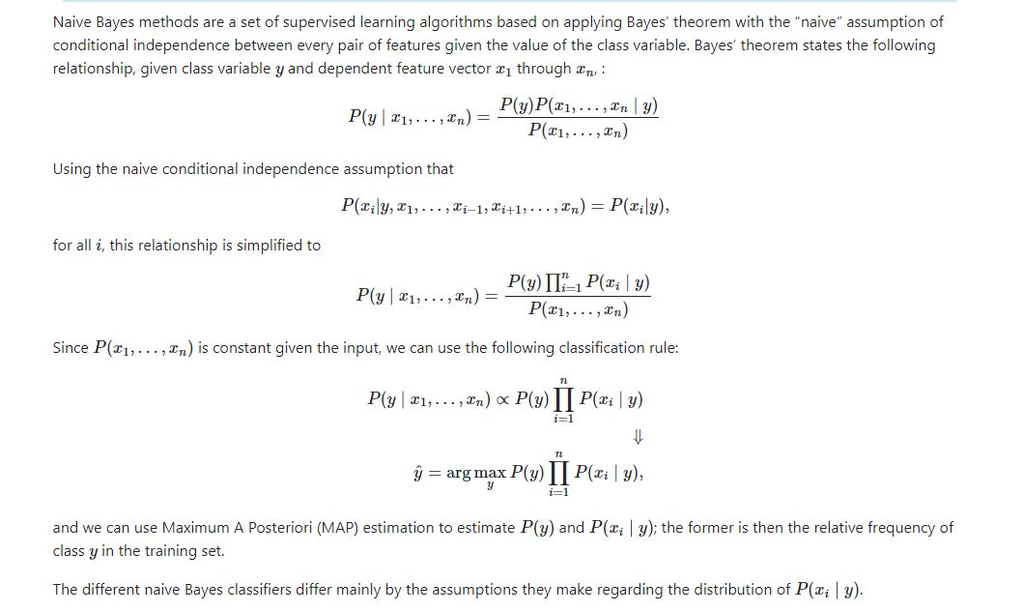

# Multinomial Naive Bayes

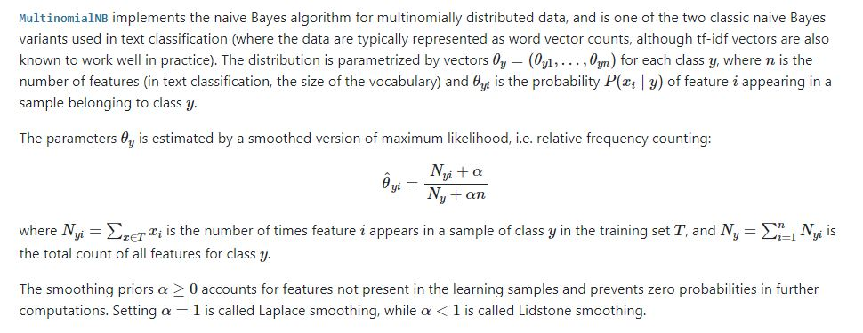

# Complement Naive Bayes

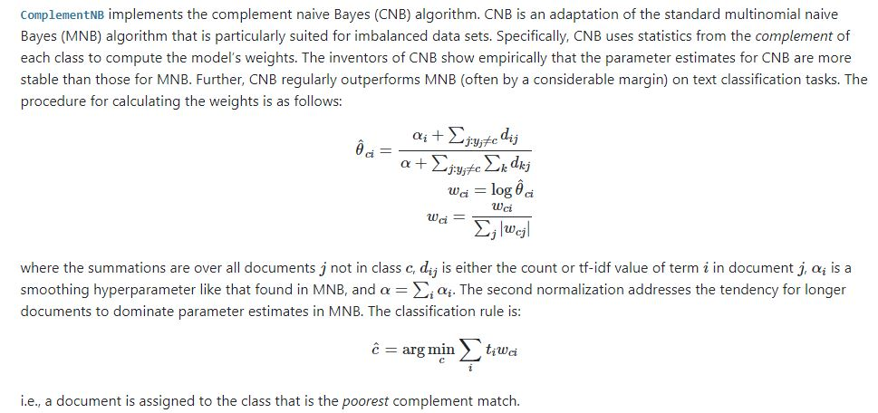

# Bernoulli Naive Bayes

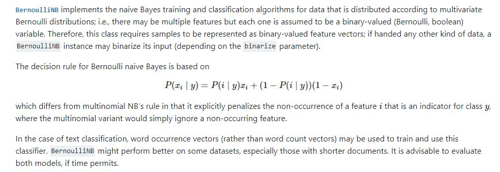

```python
from sklearn.feature_extraction.text import TfidfVectorizer, CountVectorizer, TfidfTransformer
from sklearn.naive_bayes import MultinomialNB
from sklearn.naive_bayes import ComplementNB
from sklearn.naive_bayes import BernoulliNB
from sklearn.pipeline import Pipeline
from sklearn.metrics import r2_score, mean_squared_error, mean_absolute_error
from math import sqrt
from sklearn.metrics import confusion_matrix
from sklearn.model_selection import train_test_split, cross_val_score, cross_val_predict
from sklearn.ensemble import VotingClassifier
sns.set(color_codes=True)
from sklearn.preprocessing import PolynomialFeatures
from sklearn.pipeline import make_pipeline
from sklearn.model_selection import KFold, cross_val_score, train_test_split
import random
from sklearn.metrics import accuracy_score
from collections import Counter
from sklearn.metrics import accuracy_score
```

# At first we will use Multinomial Naive Bayes model with different values of alpha and will check accuracy using development data set

# Alpha=1

```python
model_mb = Pipeline([
    ('count_vectorizer', CountVectorizer(lowercase = True, stop_words = stopwords.words('english'))),
    ('tfidf_transformer',  TfidfTransformer()), #weighs terms by importance to help with feature selection
    ('classifier', MultinomialNB(alpha=1)) ])
model_mb.fit(x_train,y_train.astype('int'))
y_pred=model_mb.predict(x_dev)
accuracy1=accuracy_score(y_dev.astype('int'),y_pred, normalize=True) * float(100)
print('\n Test accuracy is',(accuracy1))
MSE1=mean_squared_error(y_dev.astype('int'),y_pred)
print('\n Mean Squared Error', (MSE1))
```

```
 Test accuracy is 28.264919766812906

 Mean Squared Error 2.8898271130075925
```

# Alpha=2

```python
model_mb = Pipeline([
    ('count_vectorizer', CountVectorizer(lowercase = True, stop_words = stopwords.words('english'))),
    ('tfidf_transformer',  TfidfTransformer()), #weighs terms by importance to help with feature selection
    ('classifier', MultinomialNB(alpha=2)) ])
model_mb.fit(x_train,y_train.astype('int'))
y_pred=model_mb.predict(x_dev)
accuracy2=accuracy_score(y_dev.astype('int'),y_pred, normalize=True) * float(100)
print('\n****Test accuracy is',(accuracy2))
MSE2=mean_squared_error(y_dev.astype('int'),y_pred)
print('\n Mean Squared Error', (MSE2))
```

```
****Test accuracy is 27.531535682566393

 Mean Squared Error 3.0038230128680277
```

# Alpha=3

```python
model_mb = Pipeline([
    ('count_vectorizer', CountVectorizer(lowercase = True, stop_words = stopwords.words('english'))),
    ('tfidf_transformer',  TfidfTransformer()), #weighs terms by importance to help with feature selection
    ('classifier', MultinomialNB(alpha=3)) ])
model_mb.fit(x_train,y_train.astype('int'))
y_pred=model_mb.predict(x_dev)
accuracy3=accuracy_score(y_dev.astype('int'),y_pred, normalize=True) * float(100)
print('\n****Test accuracy is',(accuracy3))
MSE3=mean_squared_error(y_dev.astype('int'),y_pred)
print('\n Mean Squared Error', (MSE3))
```

```
****Test accuracy is 27.196646433078914

 Mean Squared Error 3.055039699234062
```

# Alpha=0.1

```python
model_mb = Pipeline([
    ('count_vectorizer', CountVectorizer(lowercase = True, stop_words = stopwords.words('english'))),
    ('tfidf_transformer',  TfidfTransformer()), #weighs terms by importance to help with feature selection
    ('classifier', MultinomialNB(alpha=0.1)) ])
model_mb.fit(x_train,y_train.astype('int'))
y_pred=model_mb.predict(x_dev)
accuracy4=accuracy_score(y_dev.astype('int'),y_pred, normalize=True) * float(100)
print('\n****Test accuracy is',(accuracy4))
MSE4=mean_squared_error(y_dev.astype('int'),y_pred)
print('\n Mean Squared Error', (MSE4))
```

```
****Test accuracy is 29.870418227591134

 Mean Squared Error 2.6779654226015186
```

# Alpha=0.01

```python
model_mb = Pipeline([
    ('count_vectorizer', CountVectorizer(lowercase = True, stop_words = stopwords.words('english'))),
    ('tfidf_transformer',  TfidfTransformer()), #weighs terms by importance to help with feature selection
    ('classifier', MultinomialNB(alpha=0.01)) ])
model_mb.fit(x_train,y_train.astype('int'))
y_pred=model_mb.predict(x_dev)
accuracy5=accuracy_score(y_dev.astype('int'),y_pred, normalize=True) * float(100)
print('\n****Test accuracy is',(accuracy5))
MSE5=mean_squared_error(y_dev.astype('int'),y_pred)
print('\n Mean Squared Error', (MSE5))
```

```
****Test accuracy is 30.18777837877543

 Mean Squared Error 2.614611922457947
```

# Alpha=0.001

```python
model_mb = Pipeline([
    ('count_vectorizer', CountVectorizer(lowercase = True, stop_words = stopwords.words('english'))),
    ('tfidf_transformer',  TfidfTransformer()), #weighs terms by importance to help with feature selection
    ('classifier', MultinomialNB(alpha=0.001)) ])
model_mb.fit(x_train,y_train.astype('int'))
y_pred=model_mb.predict(x_dev)
accuracy6=accuracy_score(y_dev.astype('int'),y_pred, normalize=True) * float(100)
print('\n****Test accuracy is',(accuracy6))
MSE6=mean_squared_error(y_dev.astype('int'),y_pred)
print('\n Mean Squared Error', (MSE6))
```

```
****Test accuracy is 30.17893035772716

 Mean Squared Error 2.637055846037756
```

# Highest Accuracy we found using Multinomial Naive Bayes with an alpha =0.01

# Now we will check Complement Naive Bayes model

# Alpha=1

```python
model_cm = Pipeline([
    ('count_vectorizer', CountVectorizer(lowercase = True, stop_words = stopwords.words('english'))),
    ('tfidf_transformer',  TfidfTransformer()), #weighs terms by importance to help with feature selection
    ('classifier', ComplementNB(alpha=1)) ])
model_cm.fit(x_train,y_train.astype('int'))
y_pred=model_cm.predict(x_dev)
accuracy7=accuracy_score(y_dev.astype('int'),y_pred, normalize=True) * float(100)
print('\n****Test accuracy is',(accuracy7))
MSE7=mean_squared_error(y_dev.astype('int'),y_pred)
print('\n Mean Squared Error', (MSE7))
```

```
****Test accuracy is 29.041375349747245

 Mean Squared Error 4.373144419736763
```

# Alpha=2

```python
model_cm = Pipeline([
    ('count_vectorizer', CountVectorizer(lowercase = True, stop_words = stopwords.words('english'))),
    ('tfidf_transformer',  TfidfTransformer()), #weighs terms by importance to help with feature selection
    ('classifier', ComplementNB(alpha=2)) ])
model_cm.fit(x_train,y_train.astype('int'))
y_pred=model_cm.predict(x_dev)
accuracy8=accuracy_score(y_dev.astype('int'),y_pred, normalize=True) * float(100)
print('\n****Test accuracy is',(accuracy8))
MSE8=mean_squared_error(y_dev.astype('int'),y_pred)
print('\n Mean Squared Error', (MSE8))
```

```
****Test accuracy is 29.534360371550108

 Mean Squared Error 4.261423963779874
```

# Alpha =3

```python
model_cm = Pipeline([
    ('count_vectorizer', CountVectorizer(lowercase = True, stop_words = stopwords.words('english'))),
    ('tfidf_transformer',  TfidfTransformer()), #weighs terms by importance to help with feature selection
    ('classifier', ComplementNB(alpha=3)) ])
model_cm.fit(x_train,y_train.astype('int'))
y_pred=model_cm.predict(x_dev)
accuracy9=accuracy_score(y_dev.astype('int'),y_pred, normalize=True) * float(100)
print('\n****Test accuracy is',(accuracy9))
MSE9=mean_squared_error(y_dev.astype('int'),y_pred)
print('\n Mean Squared Error', (MSE9))
```

```
****Test accuracy is 29.45122236245501

 Mean Squared Error 4.249492490868175
```

# Alpha=0.1

```python
model_cm = Pipeline([
    ('count_vectorizer', CountVectorizer(lowercase = True, stop_words = stopwords.words('english'))),
    ('tfidf_transformer',  TfidfTransformer()), #weighs terms by importance to help with feature selection
    ('classifier', ComplementNB(alpha=0.1)) ])
model_cm.fit(x_train,y_train.astype('int'))
y_pred=model_cm.predict(x_dev)
accuracy10=accuracy_score(y_dev.astype('int'),y_pred, normalize=True) * float(100)
print('\n****Test accuracy is',(accuracy10))
MSE10=mean_squared_error(y_dev.astype('int'),y_pred)
print('\n Mean Squared Error', (MSE10))
```

```
****Test accuracy is 27.23771460624637

 Mean Squared Error 4.844814058002951
```

# Alpha=0.01

```python
model_cm = Pipeline([
    ('count_vectorizer', CountVectorizer(lowercase = True, stop_words = stopwords.words('english'))),
    ('tfidf_transformer',  TfidfTransformer()), #weighs terms by importance to help with feature selection
    ('classifier', ComplementNB(alpha=0.01)) ])
model_cm.fit(x_train,y_train.astype('int'))
y_pred=model_cm.predict(x_dev)
accuracy11=accuracy_score(y_dev.astype('int'),y_pred, normalize=True) * float(100)
print('\n****Test accuracy is',(accuracy11))
MSE11=mean_squared_error(y_dev.astype('int'),y_pred)
print('\n Mean Squared Error', (MSE11))
```

```
****Test accuracy is 26.889803740876523

 Mean Squared Error 4.952601318188193
```

# Alpha=0.001

```python
model_cm = Pipeline([
    ('count_vectorizer', CountVectorizer(lowercase = True, stop_words = stopwords.words('english'))),
    ('tfidf_transformer',  TfidfTransformer()), #weighs terms by importance to help with feature selection
    ('classifier', ComplementNB(alpha=0.001)) ])
model_cm.fit(x_train,y_train.astype('int'))
y_pred=model_cm.predict(x_dev)
accuracy12=accuracy_score(y_dev.astype('int'),y_pred, normalize=True) * float(100)
print('\n****Test accuracy is',(accuracy12))
MSE12=mean_squared_error(y_dev.astype('int'),y_pred)
print('\n Mean Squared Error', (MSE12))
```

```
****Test accuracy is 26.829703975265605

 Mean Squared Error 4.967287363690393
```

# Highest Accuracy we found using Complement Naive Bayes with an alpha =2

# Now we will check Bernoulli Naive Bayes model

```python
model_bb = Pipeline([
    ('count_vectorizer', CountVectorizer(lowercase = True, stop_words = stopwords.words('english'))),
    ('tfidf_transformer',  TfidfTransformer()), #weighs terms by importance to help with feature selection
    ('classifier', BernoulliNB()) ])
model_bb.fit(x_train,y_train.astype('int'))
y_pred=model_bb.predict(x_dev)
accuracy13=accuracy_score(y_dev.astype('int'),y_pred, normalize=True) * float(100)
print('\n****Test accuracy is',(accuracy13))
MSE13=mean_squared_error(y_dev.astype('int'),y_pred)
print('\n Mean Squared Error', (MSE13))
```

```
****Test accuracy is 29.502807994604375

 Mean Squared Error 2.8365186209107116
```

# Among all the Naive Bayes model with different hyperparameter we found the best model to be Multinomial Naive Bayes with an alpha =0.01 and accuracy of 30.18777837877543 %

# Confusion Matrix, Accuracy and MSE for Naive Bayers Model

```
****Test accuracy is 30.18777837877543

 Mean Squared Error 2.614611922457947
```

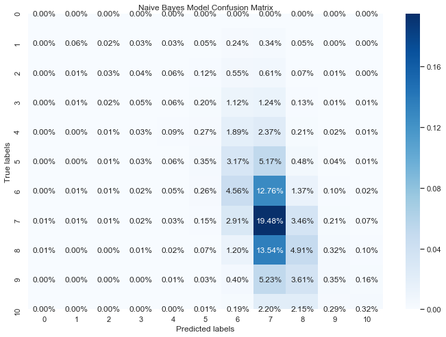

```python
model_mb = Pipeline([
    ('count_vectorizer', CountVectorizer(lowercase = True, stop_words = stopwords.words('english'))),
    ('tfidf_transformer',  TfidfTransformer()), #weighs terms by importance to help with feature selection
    ('classifier', MultinomialNB(alpha=0.01)) ])
model_mb.fit(x_train,y_train.astype('int'))
y_pred=model_mb.predict(x_dev)
accuracy5=accuracy_score(y_dev.astype('int'),y_pred, normalize=True) * float(100)
print('\n****Test accuracy is',(accuracy5))
MSE5=mean_squared_error(y_dev.astype('int'),y_pred)
print('\n Mean Squared Error', (MSE5))
cm=confusion_matrix(y_dev.astype('int'),y_pred)
fig= plt.figure(figsize=(9,6))
ax = fig.add_axes([1,1,1,1])
sns.heatmap(cm/np.sum(cm), annot=True,ax = ax,fmt='0.2%', cmap='Blues')
ax.set_xlabel('Predicted labels');ax.set_ylabel('True labels');
ax.set_title('Naive Bayes Model Confusion Matrix')
```

# Support Vector Machine Algorithm requires longer time. That is why we use 10000 train data and 2,000 development data.

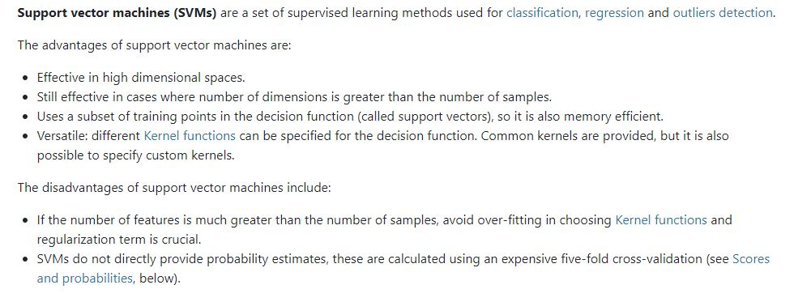

```python
from sklearn.feature_extraction.text import TfidfVectorizer, CountVectorizer, TfidfTransformer
from sklearn.svm import LinearSVC
from sklearn import svm, linear_model
```

```python
df2_train=df1_train[:10000]
df2_dev=df1_dev[:2000]
train2=df2_train['comment'].str.lower()
train_new2=train2.apply(lambda x:clean(x))
x_train2=train_new2
y_train2=df2_train['rating']
dev2=df2_dev['comment'].str.lower()
dev_new2=dev2.apply(lambda x:clean(x))
x_dev2=dev_new2
y_dev2=df2_dev['rating']
```

```python
model_svc = make_pipeline(TfidfVectorizer(ngram_range=(1,3)), svm.SVC(kernel="linear",probability=True))
model_svc.fit(x_train2, y_train2.astype('int'))
y_pred = model_svc.predict(x_dev2)
accuracy14=accuracy_score(y_dev2.astype('int'),y_pred, normalize=True) * float(100)
print('\n****Test accuracy is',(accuracy14))
MSE14=mean_squared_error(y_dev2.astype('int'),y_pred)
print('\n Mean Squared Error', (MSE14))
```

```
****Test accuracy is 29.5

 Mean Squared Error 3.0465
```

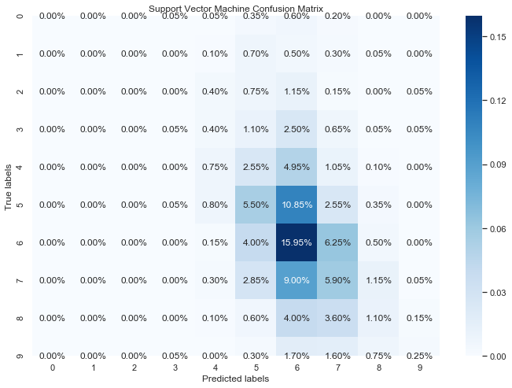

```python
cm=confusion_matrix(y_dev2.astype('int'),y_pred)
fig= plt.figure(figsize=(9,6))
ax = fig.add_axes([1,1,1,1])
sns.heatmap(cm/np.sum(cm), annot=True,ax = ax,fmt='0.2%', cmap='Blues')
ax.set_xlabel('Predicted labels');ax.set_ylabel('True labels');
ax.set_title('Support Vector Machine Confusion Matrix')
```

# Best model we have is the Multinomial Naive Bayes with an alpha =0.01

# Final Model Accuracy with test data set

```
****Test accuracy is 30.27220140065609

 Mean Squared Error 2.601590971694727
```

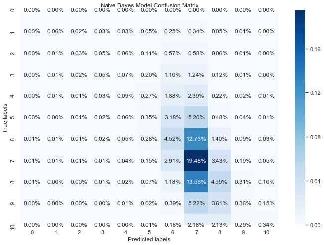

```python
model_mb = Pipeline([
    ('count_vectorizer', CountVectorizer(lowercase = True, stop_words = stopwords.words('english'))),
    ('tfidf_transformer',  TfidfTransformer()), #weighs terms by importance to help with feature selection
    ('classifier', MultinomialNB(alpha=0.01)) ])
model_mb.fit(x_train,y_train.astype('int'))
y_pred=model_mb.predict(x_test)
accuracy5=accuracy_score(y_test.astype('int'),y_pred, normalize=True) * float(100)
print('\n****Test accuracy is',(accuracy5))
MSE5=mean_squared_error(y_test.astype('int'),y_pred)
print('\n Mean Squared Error', (MSE5))
cm=confusion_matrix(y_test.astype('int'),y_pred)
fig= plt.figure(figsize=(9,6))
ax = fig.add_axes([1,1,1,1])
sns.heatmap(cm/np.sum(cm), annot=True,ax = ax,fmt='0.2%', cmap='Blues')
ax.set_xlabel('Predicted labels');ax.set_ylabel('True labels');
ax.set_title('Naive Bayes Model Confusion Matrix')
```

# Resulting accuracy is still low. One of the main reason of low accuracy might be the huge data set. Also if there was enough time to complete SVC with more data set there is a possibility of higher accuracy

# Challenges and Improvements

One of the main challenges of this project was the big amount of data. It really took a long time run because of the 15 million data. Due to this longer time period data has to confinded into reasonable amount for support vector machine. There wasn't enought time to run more models than the Naive Bayes model and Support Vector Machine. Althrough we tried different naive bayes model type and calculated accuracy with different hyper parameter. As we used a lot of data as a train set for naive bayes model it gives us a more generate idea. Also as we shuffled the data at the beginning, it gave us a good homogenous mix of results.

References:

1. https://scikit-learn.org/stable/modules/naive_bayes.html
2. https://scikit-learn.org/stable/auto_examples/model_selection/plot_confusion_matrix.html
3. https://scikit-learn.org/stable/modules/svm.html
4. https://www.geeksforgeeks.org/python-program-to-convert-a-list-to-string/
5. https://www.geeksforgeeks.org/generating-word-cloud-python/